# ML Algorithms for classification

Decision trees

Hicham Zmarrou

Notebook – http://bit.ly/2q9NPSU

[Visit my website](http://aardona.nl/) for more like this!

**References**

Most of this material is borrowed from:

- Textbook: [An Introduction to Recursive Partitioning Using the RPART Routines](https://cran.r-project.org/web/packages/rpart/vignettes/longintro.pdf)

## Exercise 1

Consider the Kyphosis data frame(type `help("kyphosis")` for more details), that contains:

- `Kyphosis`:a factor with levels “absent” and “present”" indicating if a kyphosis (a type of deformation) was present after the operation.
- **Age**: in months.
- **Number**: the number of vertebrae involved.
- **Start**: the number of the first (topmost) vertebra operated on.
1. Build a tree to classify `Kyphosis` from `Age`, `Number` and `Start`.

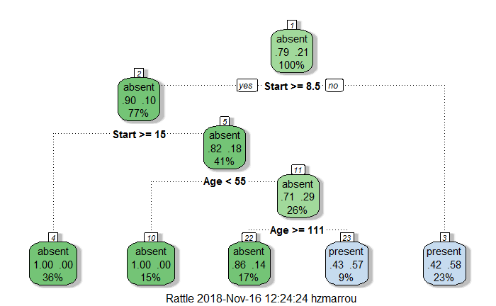

```
 Rule number: 3 [Kyphosis=present cover=19 (23%) prob=0.58]
   Start< 8.5

 Rule number: 23 [Kyphosis=present cover=7 (9%) prob=0.57]
   Start>=8.5
   Start< 14.5
   Age>=55
   Age< 111

 Rule number: 22 [Kyphosis=absent cover=14 (17%) prob=0.14]
   Start>=8.5
   Start< 14.5
   Age>=55
   Age>=111

 Rule number: 10 [Kyphosis=absent cover=12 (15%) prob=0.00]
   Start>=8.5
   Start< 14.5
   Age< 55

 Rule number: 4 [Kyphosis=absent cover=29 (36%) prob=0.00]
   Start>=8.5
   Start>=14.5
```

### How to read this these results:

Consider for example **Rule number 23**. The rule gives the path to this final node (1. if Start>=8.5; 2. if Start< 14.5; 3. if Age>=55 and if Age< 111) The `prob` means how likely will the Kyphosis present under the path of this rule. `cover= xx` means there are `xx` records split into that path (branch) of the tree at that node.

## Exercise 2

Consider the tree build in exercise 1. 1. Which variables are used to explain kyhosis presence? 2. How many observations contains the terminal nodes.

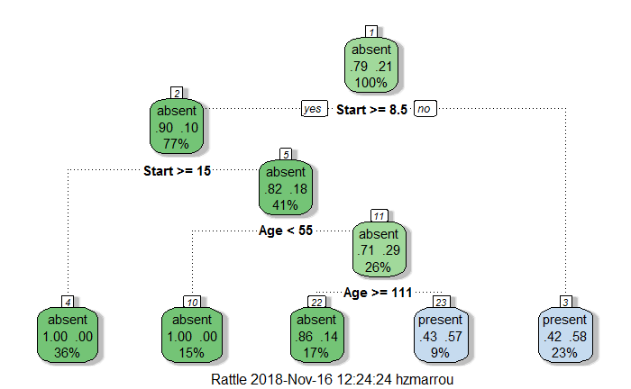

```
n= 81

node), split, n, loss, yval, (yprob)
      * denotes terminal node

 1) root 81 17 absent (0.79012346 0.20987654)
   2) Start>=8.5 62  6 absent (0.90322581 0.09677419)
     4) Start>=14.5 29  0 absent (1.00000000 0.00000000) *
     5) Start< 14.5 33  6 absent (0.81818182 0.18181818)
      10) Age< 55 12  0 absent (1.00000000 0.00000000) *
      11) Age>=55 21  6 absent (0.71428571 0.28571429)
        22) Age>=111 14  2 absent (0.85714286 0.14285714) *
        23) Age< 111 7  3 present (0.42857143 0.57142857) *
   3) Start< 8.5 19  8 present (0.42105263 0.57894737) *

Classification tree:
rpart(formula = Kyphosis ~ Age + Number + Start, data = kyphosis,
    method = "class")

Variables actually used in tree construction:
[1] Age   Start

Root node error: 17/81 = 0.20988

n= 81

        CP nsplit rel error  xerror    xstd
1 0.176471      0   1.00000 1.00000 0.21559
2 0.019608      1   0.82353 0.94118 0.21078
3 0.010000      4   0.76471 0.94118 0.21078
```

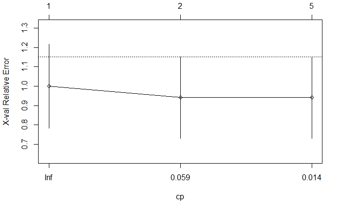

## Exercise 3

Consider the Kyphosis data frame.

1. Build a tree using the first 60 observations of kyphosis.
2. Predict the kyphosis presence for the other 21 observations.
3. Which is the misclassification rate (prediction error)

```
         test
PR        absent present
  absent      14       2
  present      3       2
```

The misclassification rate is: 23.8095238

## Exercise 4

Consider the iris data frame(type `help('iris')` for more details). 1. Build a tree to classify Species from the other variables.

```
n= 150

node), split, n, loss, yval, (yprob)
      * denotes terminal node

1) root 150 100 setosa (0.33333333 0.33333333 0.33333333)
  2) Petal.Length< 2.45 50   0 setosa (1.00000000 0.00000000 0.00000000) *
  3) Petal.Length>=2.45 100  50 versicolor (0.00000000 0.50000000 0.50000000)
    6) Petal.Width< 1.75 54   5 versicolor (0.00000000 0.90740741 0.09259259) *
    7) Petal.Width>=1.75 46   1 virginica (0.00000000 0.02173913 0.97826087) *
```

2. Plot the trees.

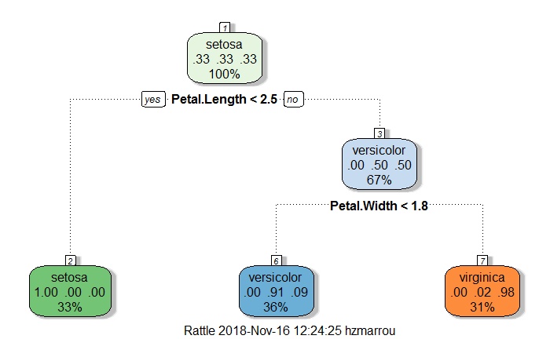

## Exercise 5

Consider the tree build in exercise 4. 1. Prune the the using median complexity parameter (cp) associated to the tree.

2. Plot in the same window the pruned and the original tree.

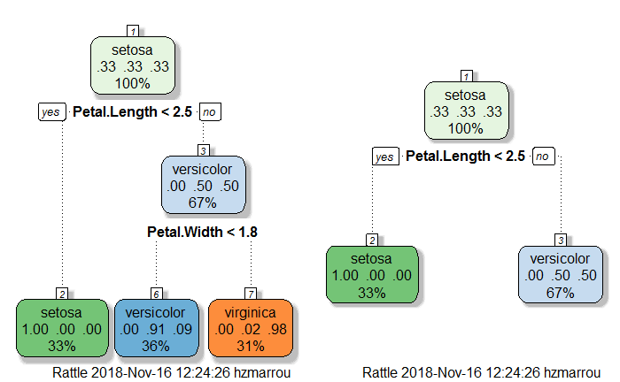

## Exercise 6

Consider the tree build in exercise 4.

1. In which terminal nodes is clasified each observations of iris?

```
  1   2   3   4   5   6   7   8   9  10  11  12  13  14  15  16  17  18
  2   2   2   2   2   2   2   2   2   2   2   2   2   2   2   2   2   2
 19  20  21  22  23  24  25  26  27  28  29  30  31  32  33  34  35  36
  2   2   2   2   2   2   2   2   2   2   2   2   2   2   2   2   2   2
 37  38  39  40  41  42  43  44  45  46  47  48  49  50  51  52  53  54
  2   2   2   2   2   2   2   2   2   2   2   2   2   2   4   4   4   4
 55  56  57  58  59  60  61  62  63  64  65  66  67  68  69  70  71  72
  4   4   4   4   4   4   4   4   4   4   4   4   4   4   4   4   5   4
 73  74  75  76  77  78  79  80  81  82  83  84  85  86  87  88  89  90
  4   4   4   4   4   4   4   4   4   4   4   4   4   4   4   4   4   4
 91  92  93  94  95  96  97  98  99 100 101 102 103 104 105 106 107 108
  4   4   4   4   4   4   4   4   4   4   5   5   5   5   5   5   4   5
109 110 111 112 113 114 115 116 117 118 119 120 121 122 123 124 125 126
  5   5   5   5   5   5   5   5   5   5   5   4   5   5   5   5   5   5
127 128 129 130 131 132 133 134 135 136 137 138 139 140 141 142 143 144
  5   5   5   4   5   5   5   4   4   5   5   5   5   5   5   5   5   5
145 146 147 148 149 150
  5   5   5   5   5   5
```

2. Which Specie has a flower of Petal.Length greater than 2.45 and Petal.Width less than 1.75.

## Exercise 7

Consider the car90 data frame(type help(‘car90’) for more details). 1. Build a tree to predict Price from the other variables.

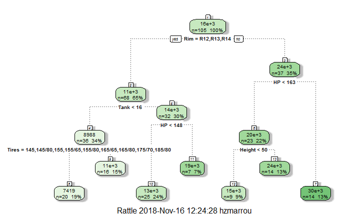

2. Plot the trees, add nodes information.

## Exercise 8

Consider the tree build in exercise 7. 1. Which variables are used to explain the price?

```
 Rule number: 10 [Price=13014.72 cover=25 (24%)]
   Rim=R12,R13,R14
   Tank>=15.65
   HP< 147.5

 Rule number: 8 [Price=7419.05 cover=20 (19%)]
   Rim=R12,R13,R14
   Tank< 15.65
   Tires=145,145/80,155,155/65,155/80,165/65,165/80,175/70,185/80

 Rule number: 9 [Price=10949.8125 cover=16 (15%)]
   Rim=R12,R13,R14
   Tank< 15.65
   Tires=185/60,185/70,195/60,195/70,195/75,205/75

 Rule number: 7 [Price=29643.0714285714 cover=14 (13%)]
   Rim=R15,R16,R17
   HP>=162.5

 Rule number: 13 [Price=23614.2857142857 cover=14 (13%)]
   Rim=R15,R16,R17
   HP< 162.5
   Height>=49.75

 Rule number: 12 [Price=14755 cover=9 (9%)]
   Rim=R15,R16,R17
   HP< 162.5
   Height< 49.75

 Rule number: 11 [Price=18886.2857142857 cover=7 (7%)]
   Rim=R12,R13,R14
   Tank>=15.65
   HP>=147.5
```

2. Which terminal nodes have a value of mean Price, less than mean(car90$Price)?

```
Call:
rpart(formula = Price ~ ., data = car90, method = "anova")
  n=105 (6 observations deleted due to missingness)

          CP nsplit rel error    xerror      xstd
1 0.50539502      0 1.0000000 1.0261960 0.1647532
2 0.11023313      1 0.4946050 0.6412737 0.1006394
3 0.06712695      2 0.3843719 0.6722886 0.1182209
4 0.06040402      3 0.3172449 0.6806018 0.1229418
5 0.02648632      4 0.2568409 0.6861309 0.1356503
6 0.01556719      5 0.2303546 0.7065111 0.1556433
7 0.01000000      6 0.2147874 0.6897999 0.1554395

Variable importance
         Rim        Tires         Tank           HP         Disp
          18           15           14           14           11
       Disp2       Weight         Type       Height     Steering
          10            3            3            2            2
    Sratio.p   Wheel.base       Length      Rear.Hd Rear.Seating
           2            2            1            1            1
       Gear2       Model2
           1            1

Node number 1: 105 observations,    complexity param=0.505395
  mean=15805.22, MSE=6.779302e+07
  left son=2 (68 obs) right son=3 (37 obs)
  Primary splits:
      Rim   splits as  LLLRRR, improve=0.5053950, (0 missing)
      Tires splits as  LLLLLLLLLLRLLLRLRLLRRRLLRRRRRR, improve=0.4721902, (0 missing)
      Disp  < 156    to the left,  improve=0.4601461, (0 missing)
      Disp2 < 2.55   to the left,  improve=0.4601461, (0 missing)
      HP    < 154    to the left,  improve=0.4548845, (0 missing)
  Surrogate splits:
      Tires splits as  LLLLLLLLLLRLLLRLRLLRRRLRRRRRRR, agree=0.876, adj=0.649, (0 split)
      Tank  < 17.8   to the left,  agree=0.848, adj=0.568, (0 split)
      Disp  < 156    to the left,  agree=0.829, adj=0.514, (0 split)
      Disp2 < 2.55   to the left,  agree=0.829, adj=0.514, (0 split)
      HP    < 126.5  to the left,  agree=0.819, adj=0.486, (0 split)

Node number 2: 68 observations,    complexity param=0.06712695
```

[output cut: 84 more lines]

```

Node number 9: 16 observations
  mean=10949.81, MSE=2905020

Node number 10: 25 observations
  mean=13014.72, MSE=4782130

Node number 11: 7 observations
  mean=18886.29, MSE=1.806262e+07

Node number 12: 9 observations
  mean=14755, MSE=9671366

Node number 13: 14 observations
  mean=23614.29, MSE=2.47642e+07
```

## Exercise 9

Consider the car.test.frame data frame (type help(‘car.test.frame’) for more details). 1. Build a tree to explain Mileage using the other variables.

```
n= 60

node), split, n, deviance, yval
      * denotes terminal node

 1) root 60 1354.58300 24.58333
   2) Disp.>=134 35  154.40000 21.40000
     4) Type=Large,Van 10   22.10000 19.30000 *
     5) Type=Compact,Medium,Sporty 25   70.56000 22.24000
      10) Price>=11522 18   26.44444 21.55556 *
      11) Price< 11522 7   14.00000 24.00000 *
   3) Disp.< 134 25  348.96000 29.04000
     6) Price>=9504.5 13   32.30769 26.23077 *
     7) Price< 9504.5 12  102.91670 32.08333 *
```

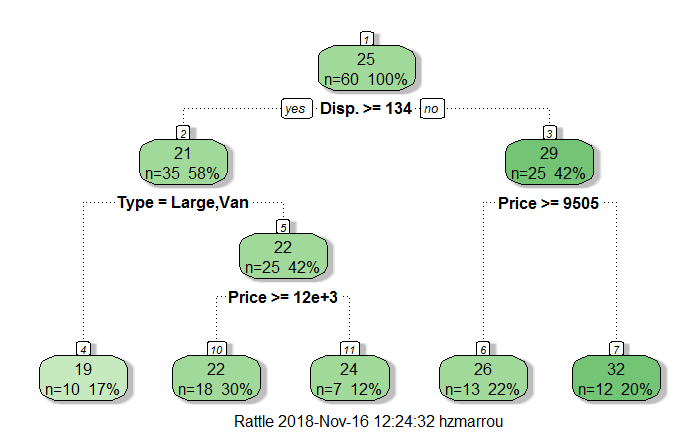

## Exercise 10

Consider the tree build in exercise 9. 1. Which is the depth of the tree (with the root node counted as depth 0). 2. Set the maximum depth of the final tree on 2

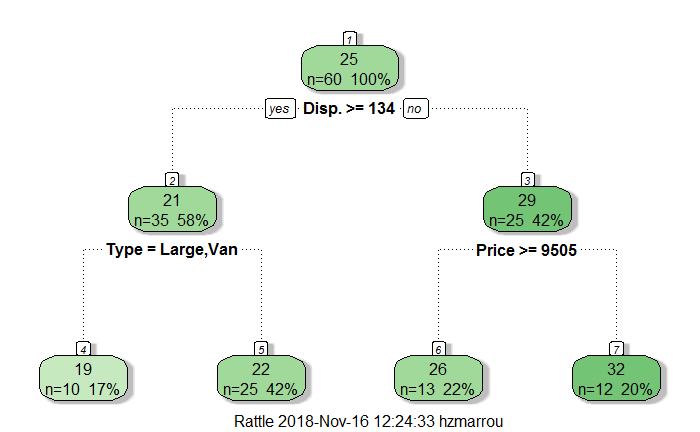

[figure not shown]